# K Nearest Neighbors

February 01, 2018

## KNN Overview

KNN is

A supervised method

An instance based learning method

- does not produce a parameterized model
- *memorizies* more than *learns*
- K, an odd integer for classification
- A 'lazy learner'

May be useful when building a *parmeterized* model is complicated

\(\mathbf {\widehat y} = f \left( \mathbf {X} , K \right)\)

Classification

- Test data category is majority vote of categories among K nearest neighbors
- A confusion matrix is used to test accuracy

Regression

- Test data value is mean of K nearest neighbors' value
- SSE, MSE, or RMSE is used to test accuracy

## Applications

OCR and image classification

Recommendations

Patterns perhaps in genetic data

Classification relationships between explanatory and response variables are complicated, but classes are preferable distinct

The Curse of Dimensionality - As the number of features grow, the number of observations required for accuracy grows exponentially - Also note ISLR p 168

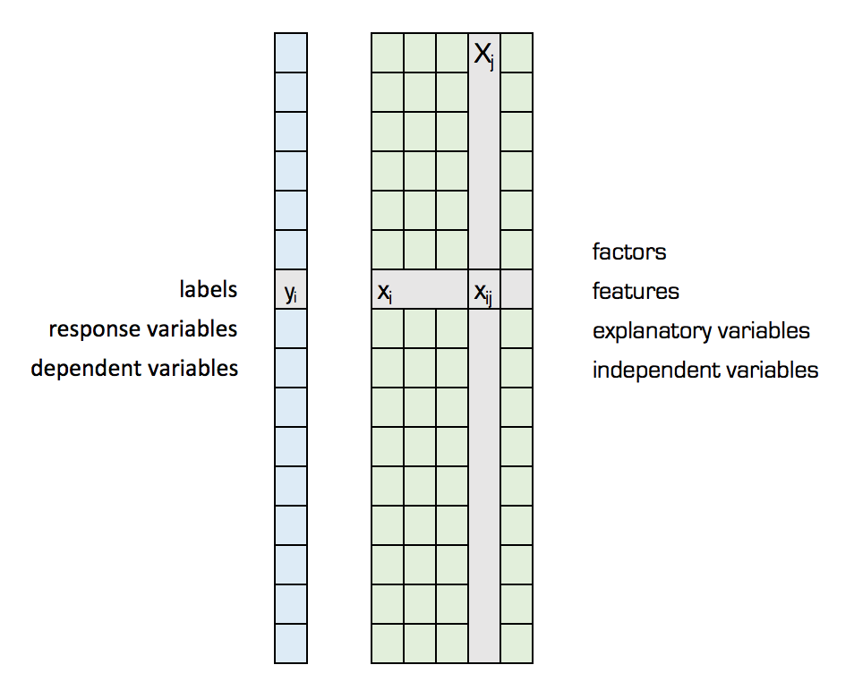

## Distances

*Nearest* is measured as distance in *feature space*

Minkowski distances

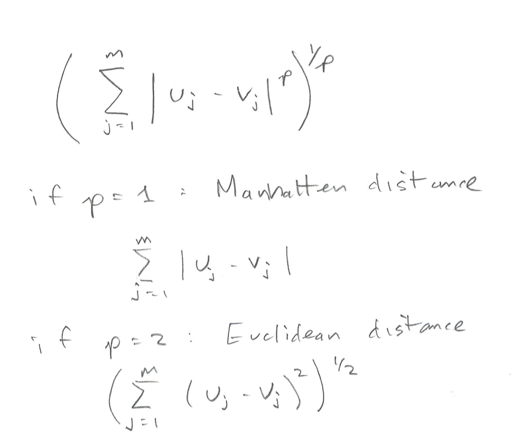

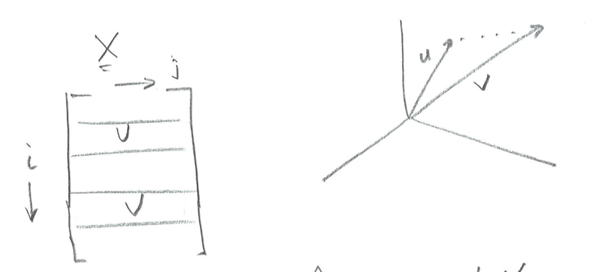

Distance between the end points of vectors **u** and **v**

Row vectors in \(\bf X\) have been denoted as \(\bf x_i\)

## Training and Testing Data Sets

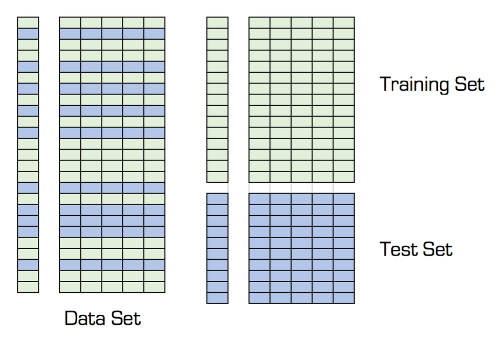

## Explanatory Variables

Must be numeric and scaled

For the \(j^{th}\) column (feature) of \(\bf X\), scale using either

\(X_j \leftarrow \frac{X_j - min\left(X_j\right) }{max\left(X_j\right) - min\left(X_j\right)}\)

\(X_j \leftarrow \frac{X_j - mean\left(X_j\right) }{std\:dev \left(X_j\right) }\)

And also \(\bf y\) similarly if numeric

## Example

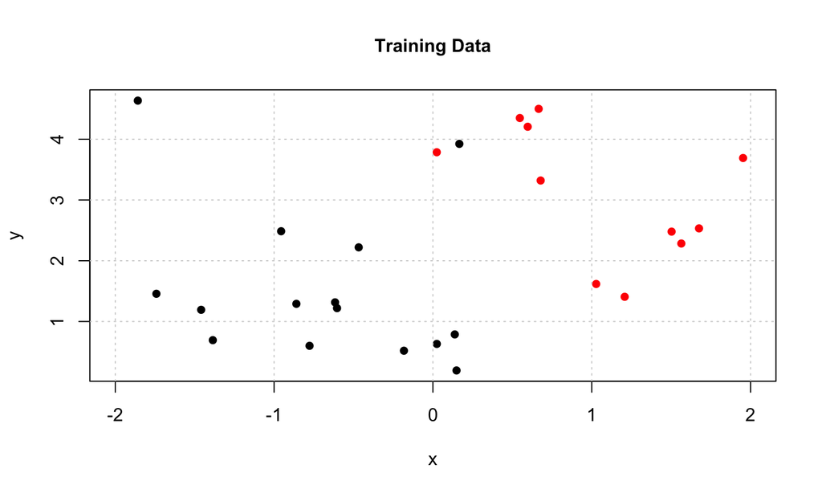

```
## [1] "nrow=  26"  "  ncol=  3"
```

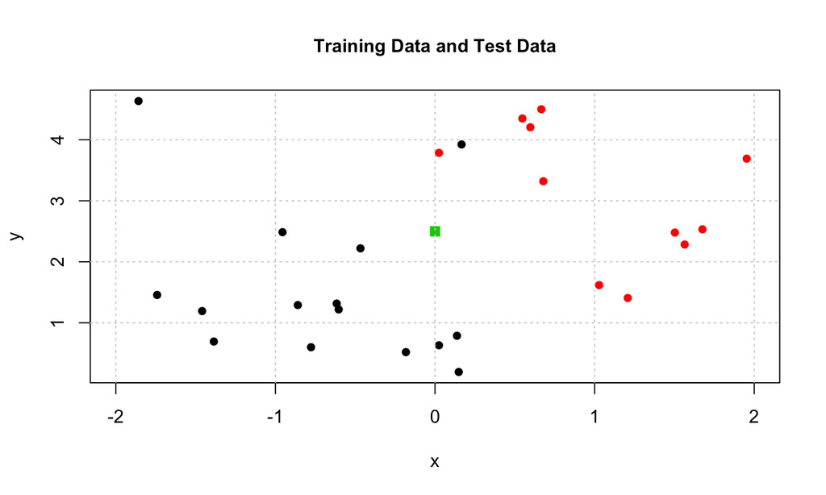

```
## [1] "nrow=  1"   "  ncol=  3"
```

```r
plot(train$x, train$y, col = train$c, pch = 16, xlim = c(-2,2), xlab = 'x', ylab = 'y', main = 'Training Data and Test Data', cex.main = 1) ; grid()
points(test$x, test$y, col = test$c, pch = 15, cex = 1.25) ; grid()  ; printDim(test)
```

## Classification

Test point (0,2.5) using k = 5

Compute the distances from the test data point to the train data points

```r
head(traink)
```

```
##              x        y    c         d
## 8  -0.46725568 2.220749 blue 0.5443425
## 9  -0.95563750 2.485800 blue 0.9557430
## 23  0.67842861 3.320524  red 1.0646716
## 12  0.02424627 3.786248  red 1.2864761
## 5  -0.61614442 1.315344 blue 1.3353070
```

```r
table(traink$c)
```

```
##
##   blue    red yellow
##      3      2      0
```

```
## [1] "nearest neighbors"
```

```
## [1] "8"  "9"  "23" "12" "5"
```

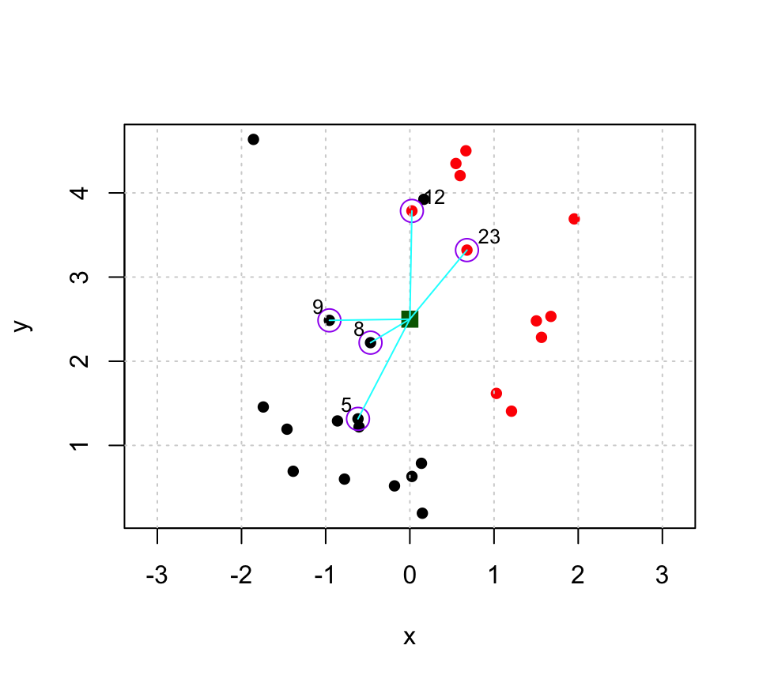

## Voronoi Diagram

k = 1

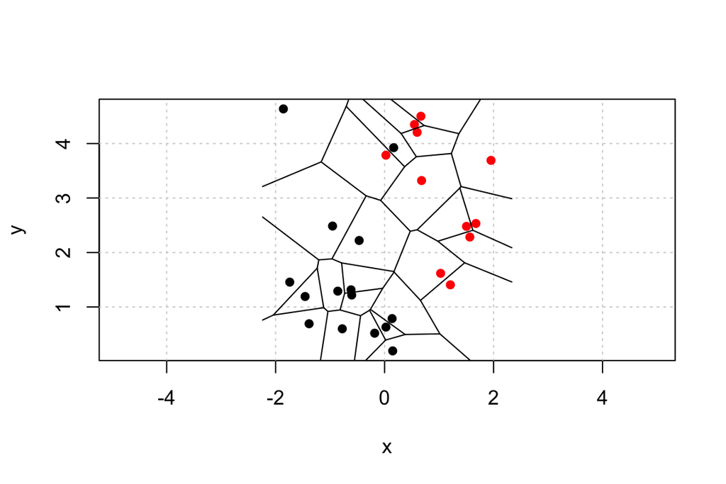

```r
plot(train$x, train$y, type="n", asp = 1, xlab = 'x', ylab = 'y') ; grid()
points(train$x, train$y,  col = train$c, pch = 16)
plot(vtess, wlines="tess", wpoints="none", number=FALSE, add=TRUE, lty=1, xlim = c(-2,2))
```

## KNN Model

Binary response, two feature classification

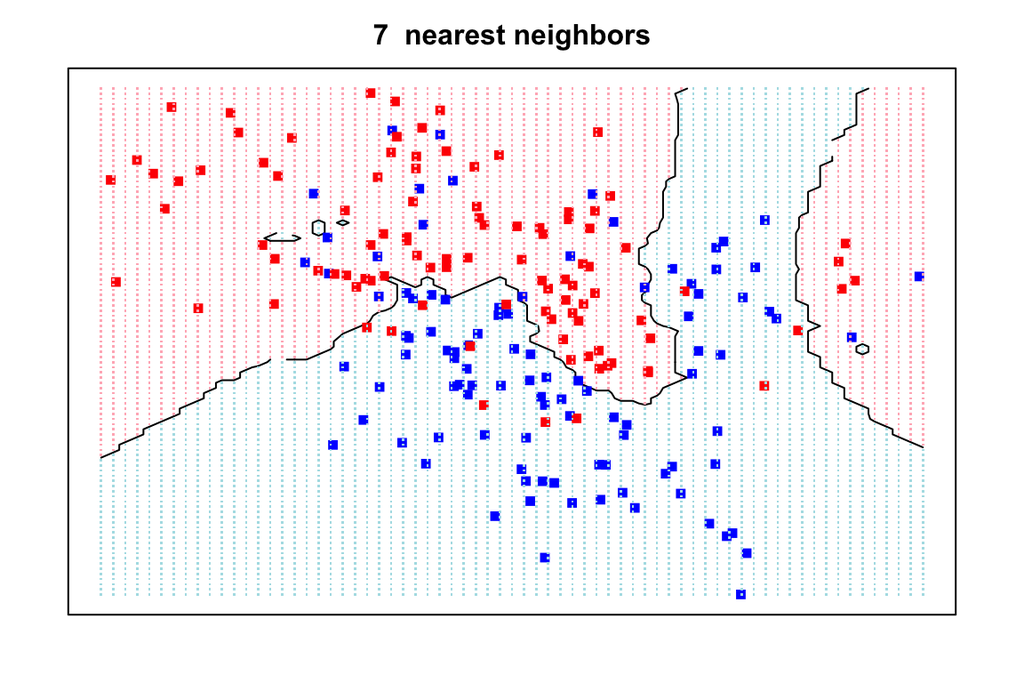

## Regression

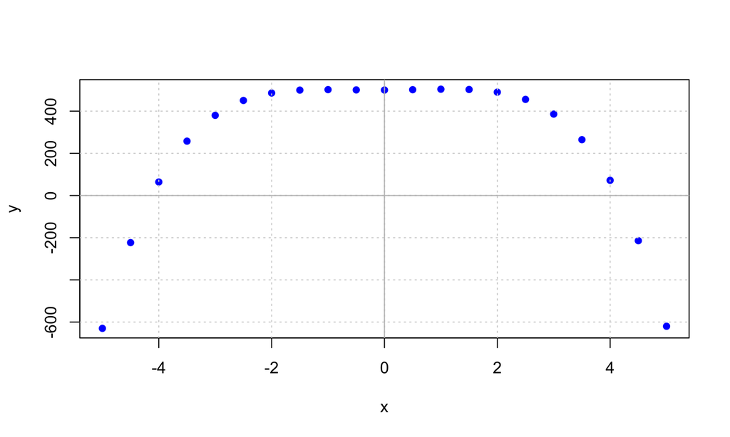

```r
n = length(x) ; d = vector()
for (i in 1:n)  {
  d[i] = abs(x[i]-xt)
}
Xk = data.frame(x,y,d)
Xk = Xk[order(Xk$d),]
head(Xk)
```

```
##      x       y   d
## 6 -2.5 450.625 0.2
## 5 -3.0 380.000 0.3
## 7 -2.0 486.000 0.7
## 4 -3.5 257.625 0.8
## 8 -1.5 499.625 1.2
## 3 -4.0  64.000 1.3
```

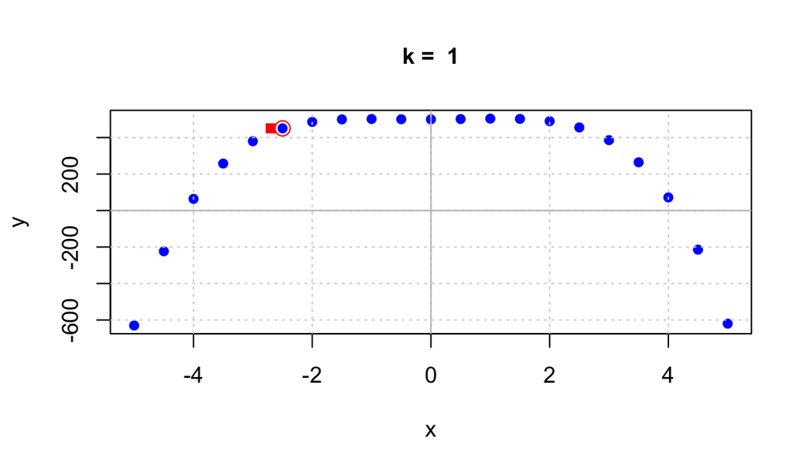

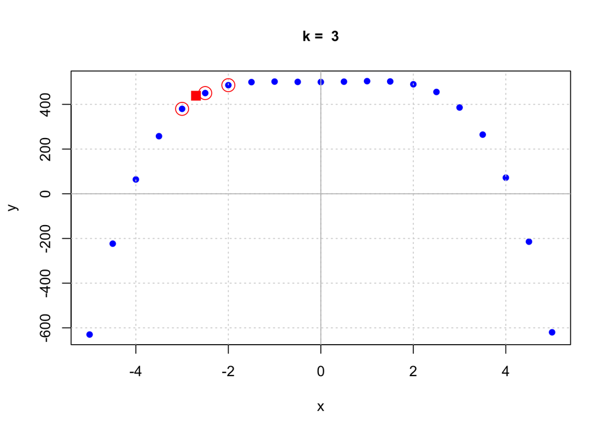

```r
k = 1
plot(x,y, col = 'blue', pch = 16, main = paste('k = ',as.character(k)),  cex.main = 1) ; grid()
yt = mean(Xk[1:k,2]) ; points(xt,yt,col='red',pch=15)
abline(h = 0, col = 'gray') ; abline(v=0, col = 'gray')
for (i in 1:k) {
  points(Xk[i,1], Xk[i,2], col = 'red', pch = 1, cex = 1.5)
}
```

Weak application since the data does not fill the space

## Iris Data Set

[Data](https://archive.ics.uci.edu/ml/datasets/Iris/)

[Watson](https://www.ibm.com/communities/analytics/watson-analytics-blog/watson-analytics-use-case-the-iris-data-set/)

[Wikipedia](https://en.wikipedia.org/wiki/Iris_flower_data_set)

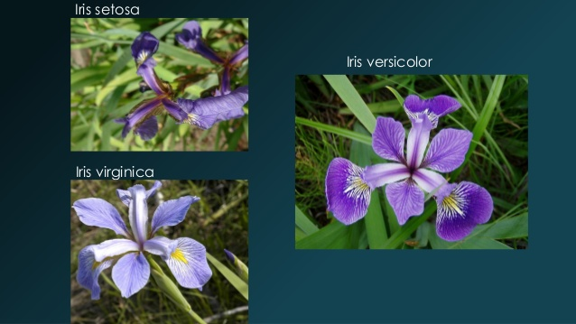

[Reference]

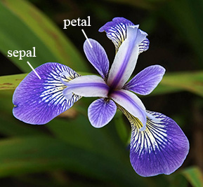

[Reference]

In Problem Set 2

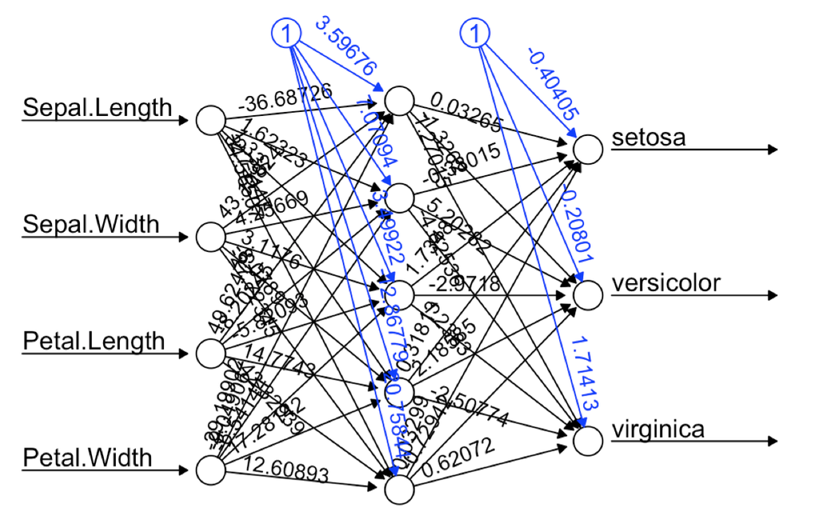

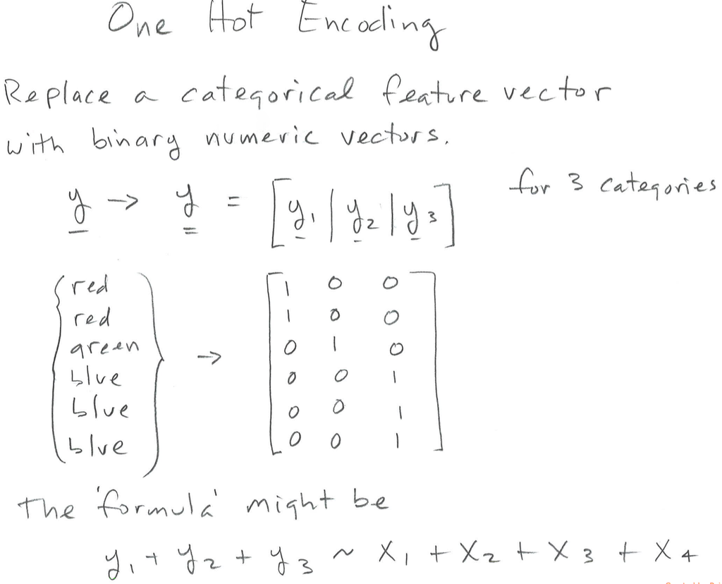

[Reference](https://www.youtube.com/watch?v=v_4KWmkwmsU&app=desktop)

## Caravan Example

Caravan Insurance Data

ISLR package data set and ISLR page 165

The Caravan Insurance Company wants to predict which prospects might likely buy their insurance product

[ISLR Description](https://cran.r-project.org/web/packages/ISLR/ISLR.pdf)

[Variable Description](http://liacs.leidenuniv.nl/~puttenpwhvander/library/cc2000/data.html)

```r
Carvan = data(Caravan) ; printDim(Caravan)
```

```
## [1] "nrow=  5822" "  ncol=  86"
```

```r
caravan = data.frame(Caravan)  # copy for scaled data
```

```r
names(Caravan) ; lineFeed('Purchase insurance ? ')
```

```
##  [1] "MOSTYPE"  "MAANTHUI" "MGEMOMV"  "MGEMLEEF" "MOSHOOFD" "MGODRK"
##  [7] "MGODPR"   "MGODOV"   "MGODGE"   "MRELGE"   "MRELSA"   "MRELOV"
## [13] "MFALLEEN" "MFGEKIND" "MFWEKIND" "MOPLHOOG" "MOPLMIDD" "MOPLLAAG"
## [19] "MBERHOOG" "MBERZELF" "MBERBOER" "MBERMIDD" "MBERARBG" "MBERARBO"
## [25] "MSKA"     "MSKB1"    "MSKB2"    "MSKC"     "MSKD"     "MHHUUR"
## [31] "MHKOOP"   "MAUT1"    "MAUT2"    "MAUT0"    "MZFONDS"  "MZPART"
## [37] "MINKM30"  "MINK3045" "MINK4575" "MINK7512" "MINK123M" "MINKGEM"
## [43] "MKOOPKLA" "PWAPART"  "PWABEDR"  "PWALAND"  "PPERSAUT" "PBESAUT"
## [49] "PMOTSCO"  "PVRAAUT"  "PAANHANG" "PTRACTOR" "PWERKT"   "PBROM"
## [55] "PLEVEN"   "PPERSONG" "PGEZONG"  "PWAOREG"  "PBRAND"   "PZEILPL"
## [61] "PPLEZIER" "PFIETS"   "PINBOED"  "PBYSTAND" "AWAPART"  "AWABEDR"
## [67] "AWALAND"  "APERSAUT" "ABESAUT"  "AMOTSCO"  "AVRAAUT"  "AAANHANG"
## [73] "ATRACTOR" "AWERKT"   "ABROM"    "ALEVEN"   "APERSONG" "AGEZONG"
## [79] "AWAOREG"  "ABRAND"   "AZEILPL"  "APLEZIER" "AFIETS"   "AINBOED"
## [85] "ABYSTAND" "Purchase"
```

```
##
##  Purchase insurance ?
```

Baseline accuracy ?

```r
table(Caravan$Purchase)
```

```
##
##   No  Yes
## 5474  348
```

```r
t = round(prop.table(table(Caravan$Purchase)),4) ; t
```

```
##
##     No    Yes
## 0.9402 0.0598
```

Just predict *no* !

```r
table(actual = Caravan$Purchase, predicted = rep(0,nrow(Caravan) ) ) ; lf()
```

```
##       predicted
## actual    0
##    No  5474
##    Yes  348
```

```r
psp(' error rate',t[2], 4)
```

```
## [1] " error rate 5.98 %"
```

```r
psp(' accuracy rate',t[1], 4)
```

```
## [1] " accuracy rate 94.02 %"
```

```r
summary(Caravan)
```

```
##     MOSTYPE         MAANTHUI         MGEMOMV         MGEMLEEF
##  Min.   : 1.00   Min.   : 1.000   Min.   :1.000   Min.   :1.000
##  1st Qu.:10.00   1st Qu.: 1.000   1st Qu.:2.000   1st Qu.:2.000
##  Median :30.00   Median : 1.000   Median :3.000   Median :3.000
##  Mean   :24.25   Mean   : 1.111   Mean   :2.679   Mean   :2.991
##  3rd Qu.:35.00   3rd Qu.: 1.000   3rd Qu.:3.000   3rd Qu.:3.000
##  Max.   :41.00   Max.   :10.000   Max.   :5.000   Max.   :6.000
##     MOSHOOFD          MGODRK           MGODPR          MGODOV
##  Min.   : 1.000   Min.   :0.0000   Min.   :0.000   Min.   :0.00
##  1st Qu.: 3.000   1st Qu.:0.0000   1st Qu.:4.000   1st Qu.:0.00
##  Median : 7.000   Median :0.0000   Median :5.000   Median :1.00
##  Mean   : 5.774   Mean   :0.6965   Mean   :4.627   Mean   :1.07
##  3rd Qu.: 8.000   3rd Qu.:1.0000   3rd Qu.:6.000   3rd Qu.:2.00
##  Max.   :10.000   Max.   :9.0000   Max.   :9.000   Max.   :5.00
##      MGODGE          MRELGE          MRELSA           MRELOV
##  Min.   :0.000   Min.   :0.000   Min.   :0.0000   Min.   :0.00
##  1st Qu.:2.000   1st Qu.:5.000   1st Qu.:0.0000   1st Qu.:1.00
##  Median :3.000   Median :6.000   Median :1.0000   Median :2.00
##  Mean   :3.259   Mean   :6.183   Mean   :0.8835   Mean   :2.29
##  3rd Qu.:4.000   3rd Qu.:7.000   3rd Qu.:1.0000   3rd Qu.:3.00
##  Max.   :9.000   Max.   :9.000   Max.   :7.0000   Max.   :9.00
##     MFALLEEN        MFGEKIND       MFWEKIND      MOPLHOOG
##  Min.   :0.000   Min.   :0.00   Min.   :0.0   Min.   :0.000
##  1st Qu.:0.000   1st Qu.:2.00   1st Qu.:3.0   1st Qu.:0.000
##  Median :2.000   Median :3.00   Median :4.0   Median :1.000
##  Mean   :1.888   Mean   :3.23   Mean   :4.3   Mean   :1.461
##  3rd Qu.:3.000   3rd Qu.:4.00   3rd Qu.:6.0   3rd Qu.:2.000
##  Max.   :9.000   Max.   :9.00   Max.   :9.0   Max.   :9.000
##     MOPLMIDD        MOPLLAAG        MBERHOOG        MBERZELF
##  Min.   :0.000   Min.   :0.000   Min.   :0.000   Min.   :0.000
##  1st Qu.:2.000   1st Qu.:3.000   1st Qu.:0.000   1st Qu.:0.000
##  Median :3.000   Median :5.000   Median :2.000   Median :0.000
##  Mean   :3.351   Mean   :4.572   Mean   :1.895   Mean   :0.398
##  3rd Qu.:4.000   3rd Qu.:6.000   3rd Qu.:3.000   3rd Qu.:1.000
##  Max.   :9.000   Max.   :9.000   Max.   :9.000   Max.   :5.000
##     MBERBOER         MBERMIDD        MBERARBG       MBERARBO
##  Min.   :0.0000   Min.   :0.000   Min.   :0.00   Min.   :0.000
##  1st Qu.:0.0000   1st Qu.:2.000   1st Qu.:1.00   1st Qu.:1.000
##  Median :0.0000   Median :3.000   Median :2.00   Median :2.000
##  Mean   :0.5223   Mean   :2.899   Mean   :2.22   Mean   :2.306
```

[output cut: 99 more lines]

```
##  Max.   :1.000000   Max.   :1.000000   Max.   :2.000000   Max.   :7.0000
##     AZEILPL             APLEZIER            AFIETS
##  Min.   :0.0000000   Min.   :0.000000   Min.   :0.00000
##  1st Qu.:0.0000000   1st Qu.:0.000000   1st Qu.:0.00000
##  Median :0.0000000   Median :0.000000   Median :0.00000
##  Mean   :0.0005153   Mean   :0.006012   Mean   :0.03178
##  3rd Qu.:0.0000000   3rd Qu.:0.000000   3rd Qu.:0.00000
##  Max.   :1.0000000   Max.   :2.000000   Max.   :3.00000
##     AINBOED            ABYSTAND       Purchase
##  Min.   :0.000000   Min.   :0.00000   No :5474
##  1st Qu.:0.000000   1st Qu.:0.00000   Yes: 348
##  Median :0.000000   Median :0.00000
##  Mean   :0.007901   Mean   :0.01426
##  3rd Qu.:0.000000   3rd Qu.:0.00000
##  Max.   :2.000000   Max.   :2.00000
```

Which normalization method ?

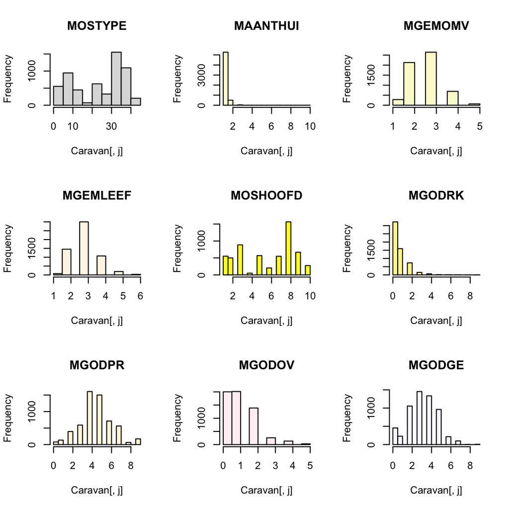

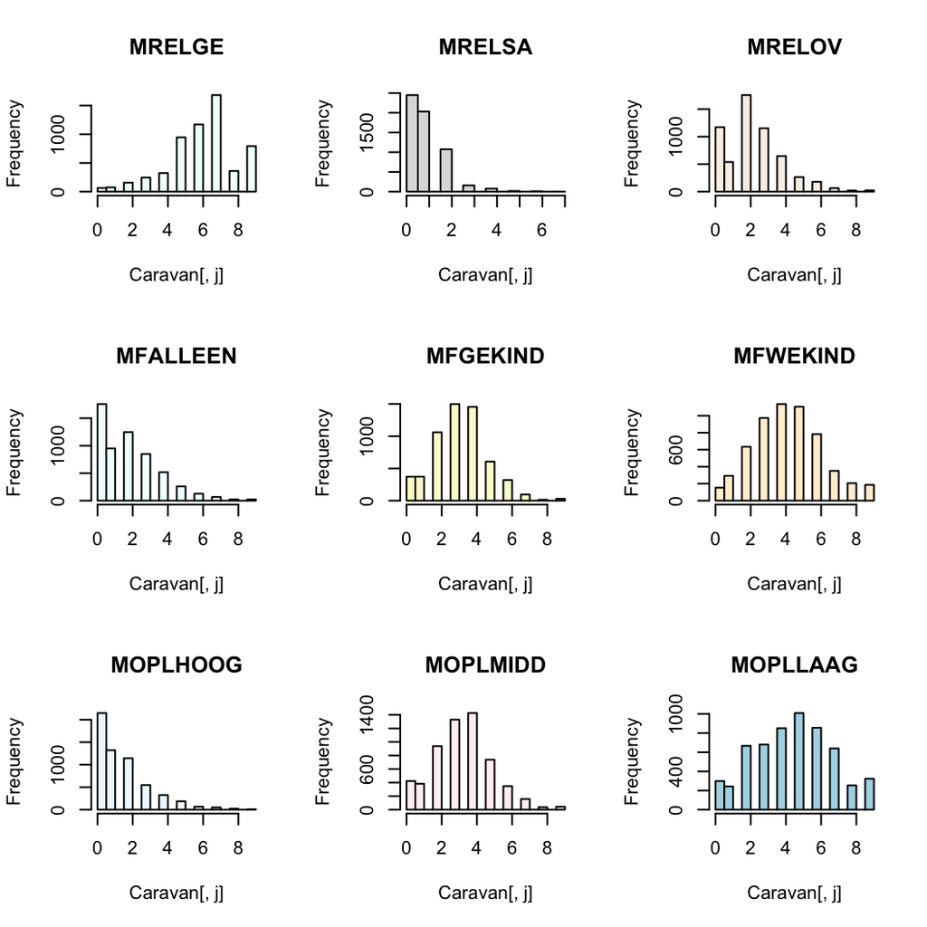

```r
nc = ncol(Caravan) ; p = nc - 1  ; n = nrow(Caravan) ; lf()
for (j in 1:p) {
  caravan[,j] = ScaleNorm(Caravan[,j])
}
nc = ncol(caravan) ; p = nc - 1  ; n = nrow(caravan)
psi('number columns',nc) ; psi('number parameters',p) ; psi('number rows',n)
printDim(caravan)
```

```r
summary(caravan)
```

```
##     MOSTYPE         MAANTHUI         MGEMOMV         MGEMLEEF
##  Min.   : 1.00   Min.   : 1.000   Min.   :1.000   Min.   :1.000
##  1st Qu.:10.00   1st Qu.: 1.000   1st Qu.:2.000   1st Qu.:2.000
##  Median :30.00   Median : 1.000   Median :3.000   Median :3.000
##  Mean   :24.25   Mean   : 1.111   Mean   :2.679   Mean   :2.991
##  3rd Qu.:35.00   3rd Qu.: 1.000   3rd Qu.:3.000   3rd Qu.:3.000
##  Max.   :41.00   Max.   :10.000   Max.   :5.000   Max.   :6.000
##     MOSHOOFD          MGODRK           MGODPR          MGODOV
##  Min.   : 1.000   Min.   :0.0000   Min.   :0.000   Min.   :0.00
##  1st Qu.: 3.000   1st Qu.:0.0000   1st Qu.:4.000   1st Qu.:0.00
##  Median : 7.000   Median :0.0000   Median :5.000   Median :1.00
##  Mean   : 5.774   Mean   :0.6965   Mean   :4.627   Mean   :1.07
##  3rd Qu.: 8.000   3rd Qu.:1.0000   3rd Qu.:6.000   3rd Qu.:2.00
##  Max.   :10.000   Max.   :9.0000   Max.   :9.000   Max.   :5.00
##      MGODGE          MRELGE          MRELSA           MRELOV
##  Min.   :0.000   Min.   :0.000   Min.   :0.0000   Min.   :0.00
##  1st Qu.:2.000   1st Qu.:5.000   1st Qu.:0.0000   1st Qu.:1.00
##  Median :3.000   Median :6.000   Median :1.0000   Median :2.00
##  Mean   :3.259   Mean   :6.183   Mean   :0.8835   Mean   :2.29
##  3rd Qu.:4.000   3rd Qu.:7.000   3rd Qu.:1.0000   3rd Qu.:3.00
##  Max.   :9.000   Max.   :9.000   Max.   :7.0000   Max.   :9.00
##     MFALLEEN        MFGEKIND       MFWEKIND      MOPLHOOG
##  Min.   :0.000   Min.   :0.00   Min.   :0.0   Min.   :0.000
##  1st Qu.:0.000   1st Qu.:2.00   1st Qu.:3.0   1st Qu.:0.000
##  Median :2.000   Median :3.00   Median :4.0   Median :1.000
##  Mean   :1.888   Mean   :3.23   Mean   :4.3   Mean   :1.461
##  3rd Qu.:3.000   3rd Qu.:4.00   3rd Qu.:6.0   3rd Qu.:2.000
##  Max.   :9.000   Max.   :9.00   Max.   :9.0   Max.   :9.000
##     MOPLMIDD        MOPLLAAG        MBERHOOG        MBERZELF
##  Min.   :0.000   Min.   :0.000   Min.   :0.000   Min.   :0.000
##  1st Qu.:2.000   1st Qu.:3.000   1st Qu.:0.000   1st Qu.:0.000
##  Median :3.000   Median :5.000   Median :2.000   Median :0.000
##  Mean   :3.351   Mean   :4.572   Mean   :1.895   Mean   :0.398
##  3rd Qu.:4.000   3rd Qu.:6.000   3rd Qu.:3.000   3rd Qu.:1.000
##  Max.   :9.000   Max.   :9.000   Max.   :9.000   Max.   :5.000
##     MBERBOER         MBERMIDD        MBERARBG       MBERARBO
##  Min.   :0.0000   Min.   :0.000   Min.   :0.00   Min.   :0.000
##  1st Qu.:0.0000   1st Qu.:2.000   1st Qu.:1.00   1st Qu.:1.000
##  Median :0.0000   Median :3.000   Median :2.00   Median :2.000
##  Mean   :0.5223   Mean   :2.899   Mean   :2.22   Mean   :2.306
```

[output cut: 99 more lines]

```
##  Max.   :1.000000   Max.   :1.000000   Max.   :2.000000   Max.   :7.0000
##     AZEILPL             APLEZIER            AFIETS
##  Min.   :0.0000000   Min.   :0.000000   Min.   :0.00000
##  1st Qu.:0.0000000   1st Qu.:0.000000   1st Qu.:0.00000
##  Median :0.0000000   Median :0.000000   Median :0.00000
##  Mean   :0.0005153   Mean   :0.006012   Mean   :0.03178
##  3rd Qu.:0.0000000   3rd Qu.:0.000000   3rd Qu.:0.00000
##  Max.   :1.0000000   Max.   :2.000000   Max.   :3.00000
##     AINBOED            ABYSTAND       Purchase
##  Min.   :0.000000   Min.   :0.00000   No :5474
##  1st Qu.:0.000000   1st Qu.:0.00000   Yes: 348
##  Median :0.000000   Median :0.00000
##  Mean   :0.007901   Mean   :0.01426
##  3rd Qu.:0.000000   3rd Qu.:0.00000
##  Max.   :2.000000   Max.   :2.00000
```

```r
str(caravan)
```

```
## 'data.frame':    5822 obs. of  86 variables:
##  $ MOSTYPE : num  33 37 37 9 40 23 39 33 33 11 ...
##  $ MAANTHUI: num  1 1 1 1 1 1 2 1 1 2 ...
##  $ MGEMOMV : num  3 2 2 3 4 2 3 2 2 3 ...
##  $ MGEMLEEF: num  2 2 2 3 2 1 2 3 4 3 ...
##  $ MOSHOOFD: num  8 8 8 3 10 5 9 8 8 3 ...
##  $ MGODRK  : num  0 1 0 2 1 0 2 0 0 3 ...
##  $ MGODPR  : num  5 4 4 3 4 5 2 7 1 5 ...
##  $ MGODOV  : num  1 1 2 2 1 0 0 0 3 0 ...
##  $ MGODGE  : num  3 4 4 4 4 5 5 2 6 2 ...
##  $ MRELGE  : num  7 6 3 5 7 0 7 7 6 7 ...
##  $ MRELSA  : num  0 2 2 2 1 6 2 2 0 0 ...
##  $ MRELOV  : num  2 2 4 2 2 3 0 0 3 2 ...
##  $ MFALLEEN: num  1 0 4 2 2 3 0 0 3 2 ...
##  $ MFGEKIND: num  2 4 4 3 4 5 3 5 3 2 ...
```

[output cut: 72 more lines]

Training and test sets using caTools package

```r
set.seed(101010)
split = sample.split(caravan$Purchase, SplitRatio = .80)
table(split)
```

```
## split
## FALSE  TRUE
##  1165  4657
```

```r
Xtrain = subset(caravan, split == TRUE)
Xtest = subset(caravan, split == FALSE)
lf() ; printDim(Xtrain) ; printDim(Xtest)
```

```
## [1] "nrow=  4657" "  ncol=  86"
```

```
## [1] "nrow=  1165" "  ncol=  86"
```

Check balance of training and test sets

```r
table(Xtrain$Purchase) ; table(Xtest$Purchase)
```

```
##
##   No  Yes
## 4379  278
```

```
##
##   No  Yes
## 1095   70
```

```r
round(prop.table(table(Xtrain$Purchase)),4) ; round(prop.table(table(Xtest$Purchase)),4)
```

```
##
##     No    Yes
## 0.9403 0.0597
```

```
##
##     No    Yes
## 0.9399 0.0601
```

```r
yTest = Xtest$Purchase  ; Xtest$Purchase = NULL
yTrain = Xtrain$Purchase  ; Xtrain$Purchase = NULL
length(yTrain) ; length(yTest)
```

```
## [1] 4657
```

```
## [1] 1165
```

```r
round(prop.table(table(yTrain)),4) ; lf() ; round(prop.table(table(yTest)),4)
```

```
## yTrain
##     No    Yes
## 0.9403 0.0597
```

```
## yTest
##     No    Yes
## 0.9399 0.0601
```

KNN Method from CLASS package

```r
set.seed(101010)
pred = knn(Xtrain, Xtest, yTrain, k = 3)
```

```r
t = table(actual = yTest, predicted = pred)
t
```

```
##       predicted
## actual   No  Yes
##    No  1080   15
##    Yes   67    3
```

```r
accuracy = sum(diag(t)) / sum(t)
psr('accuracy rate',accuracy,4)
```

```
## [1] "accuracy rate 0.9296"
```

```r
psr('error rate',1-accuracy,4)
```

```
## [1] "error rate 0.0704"
```

```r
acc(t,TRUE)
```

```
##            predicted
## actual      pred false pred true
##   act false       1080        15
##   act true          67         3
## [1] "Num of Observ" "1165"
## [1] "Sensitivity or Recall" "0.0429"
## [1] "Specificity" "0.9863"
## [1] "Overall Accuracy" "0.9296"
## [1] "True Negative" "1080"
## [1] "False Negative" "67"
## [1] "False Positive" "15"
## [1] "True Positive" "3"
## [1] "Precision" "0.1667"
## [1] "Overall Error Rate" "0.0704"
## [1] "False Negative Error Rate" "0.9571"
## [1] "False Positive Error Rate" "0.0137"
```

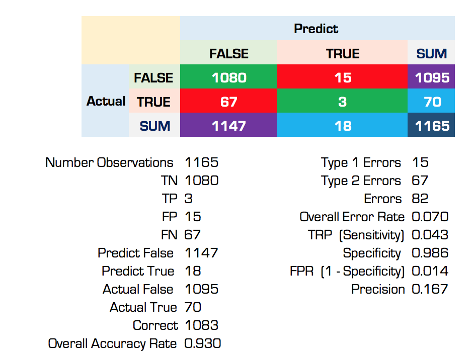

But the base accuracy rate of always choosing *no* is 94%

But what if the sales people contacted only those prospects that were *predicted* to buy ?

A key result of the experiment is leveraging the *precision*

```r
predBuy = t[3] + t[4]
predBuy
```

```
## [1] 18
```

```r
salesCloseRate = t[4] / predBuy
psr('sales close rate', salesCloseRate, 4)
```

```
## [1] "sales close rate 0.1667"
```

So by calling on these prospects the close rate is much greater than of calling on random prospects !